# Getting Started with SCANER

woolingxiang & PoShine

2024-07-27

## Tutorial SCANER; Dataset: SmartSeq2 scRNA seq of HNSCC

SCANER represents a novel marker-free approach for the identification of malignant cells within the tumor ecosystem. This method capitalizes on the substantial gene expression variations caused by genomic instability and integrates genes across the entire genome to mitigate the noise introduced by stochastic dropout events at the single-cell resolution. It demonstrates an ability to detect copy number variations (CNVs) in malignant cells with high consistency against whole exome sequencing (WES) results.

#### Installing the SCANER library

```r
install.packages("devtools")
devtools::install_github('woolingxiang/SCANER')
```

#### Sample dataset: Download

SCANER is recommended to be used with a Seurat object containing cell cluster labels as input data.

As example, we will use a dataset containing 5,902 cells from HNSCC patients.

The expression matrix and cell characteristics can be downloaded from the GSE103322.

The expression is provided as log2(TPM/10+1) in the file “HNSCC_all_data.txt”. Furthermore, the cell-type classification is also available in the file “HNSCC_all_data.txt”.

In a first step we load the expression matrix and cell-type classification:

```r
pheno = t(read.table('./HNSCC_all_data.txt', header = T, row.names = 1, sep = '\t', quote = "\'", stringsAsFactors = F, comment.char = "'"))
dim(pheno)
```

```
## [1] 5902    5
```

```r
head(pheno)
```

```
##                        processed by Maxima enzyme Lymph node
## HN28_P15_D06_S330_comb "1"                        "1"
## HN28_P6_G05_S173_comb  "1"                        "0"
## HN26_P14_D11_S239_comb "1"                        "1"
## HN26_P14_H05_S281_comb "1"                        "1"
## HN26_P25_H09_S189_comb "1"                        "1"
## HN26_P14_H06_S282_comb "1"                        "1"
##                        classified  as cancer cell
## HN28_P15_D06_S330_comb "0"
## HN28_P6_G05_S173_comb  "0"
## HN26_P14_D11_S239_comb "1"
## HN26_P14_H05_S281_comb "0"
## HN26_P25_H09_S189_comb "1"
## HN26_P14_H06_S282_comb "1"
##                        classified as non-cancer cells non-cancer cell type
## HN28_P15_D06_S330_comb "1"                            "Fibroblast"
## HN28_P6_G05_S173_comb  "1"                            "Fibroblast"
## HN26_P14_D11_S239_comb "0"                            "0"
## HN26_P14_H05_S281_comb "1"                            "Fibroblast"
## HN26_P25_H09_S189_comb "0"                            "0"
## HN26_P14_H06_S282_comb "0"                            "0"
```

The matrix holds the expression of 23,686 genes in 5,902 cells.

```r
mat = read.table('./HNSCC_all_data.txt', header = F, row.names = 1, sep = '\t', quote = "\'", stringsAsFactors = F, skip = 6)
colnames(mat) = rownames(pheno)
dim(mat)
```

```
## [1] 23686  5902
```

```r
mat[1:5,1:3]
```

```
##          HN28_P15_D06_S330_comb HN28_P6_G05_S173_comb HN26_P14_D11_S239_comb
## C9orf152                 0.0000                0.0000                0.42761
## RPS11                    6.0037                7.3006                7.28850
## ELMO2                    0.0000                0.0000                0.00000
## CREB3L1                  0.0000                0.0000                0.00000
## PNMA1                    5.1474                5.3329                2.83370
```

#### Sample dataset: Processing

To generate a Seurat object.

```r
library(Seurat)
scRNA = CreateSeuratObject(counts = mat,
  project = "GSE103322",
  min.cells = 3,
  min.features = 200,
  meta.data = data.frame(pheno))
scRNA
```

```
## An object of class Seurat
## 21519 features across 5902 samples within 1 assay
## Active assay: RNA (21519 features, 0 variable features)
```

The malignant cell labels in the article were simply annotated according to the established criteria.

```r
scRNA$malignancy.annotation = plyr::revalue(as.character(scRNA$'classified..as.cancer.cell'),
                                            replace = c('1'='malignant', '0'='non-malignant'))
head(scRNA@meta.data)
```

```
##                        orig.ident nCount_RNA nFeature_RNA
## HN28_P15_D06_S330_comb       HN28  10863.073         4286
## HN28_P6_G05_S173_comb        HN28   8215.891         2723
## HN26_P14_D11_S239_comb       HN26  14730.809         6964
## HN26_P14_H05_S281_comb       HN26   8777.818         3451
## HN26_P25_H09_S189_comb       HN26  13058.068         7354
## HN26_P14_H06_S282_comb       HN26  15784.340         7744
##                        processed.by.Maxima.enzyme Lymph.node
## HN28_P15_D06_S330_comb                          1          1
## HN28_P6_G05_S173_comb                           1          0
## HN26_P14_D11_S239_comb                          1          1
## HN26_P14_H05_S281_comb                          1          1
## HN26_P25_H09_S189_comb                          1          1
## HN26_P14_H06_S282_comb                          1          1
##                        classified..as.cancer.cell
## HN28_P15_D06_S330_comb                          0
## HN28_P6_G05_S173_comb                           0
## HN26_P14_D11_S239_comb                          1
## HN26_P14_H05_S281_comb                          0
## HN26_P25_H09_S189_comb                          1
## HN26_P14_H06_S282_comb                          1
##                        classified.as.non.cancer.cells non.cancer.cell.type
## HN28_P15_D06_S330_comb                              1           Fibroblast
## HN28_P6_G05_S173_comb                               1           Fibroblast
## HN26_P14_D11_S239_comb                              0                    0
## HN26_P14_H05_S281_comb                              1           Fibroblast
## HN26_P25_H09_S189_comb                              0                    0
## HN26_P14_H06_S282_comb                              0                    0
##                        malignancy.annotation
## HN28_P15_D06_S330_comb         non-malignant
## HN28_P6_G05_S173_comb          non-malignant
## HN26_P14_D11_S239_comb             malignant
## HN26_P14_H05_S281_comb         non-malignant
## HN26_P25_H09_S189_comb             malignant
## HN26_P14_H06_S282_comb             malignant
```

Here, we omit the ‘NormalizeData’ step

```r
library(dplyr)
scRNA = scRNA %>% FindVariableFeatures(verbose=FALSE) %>% ScaleData(verbose=FALSE) %>% RunPCA(verbose = FALSE) %>%
  RunTSNE(reduction = "pca", dims = 1:30, verbose=FALSE) %>%
  RunUMAP(reduction = "pca", dims = 1:30, verbose=FALSE) %>%
  FindNeighbors(reduction = "pca", dims = 1:30, verbose = FALSE) %>%
  FindClusters(resolution = seq(0.4,0.8,0.1), verbose = FALSE)
```

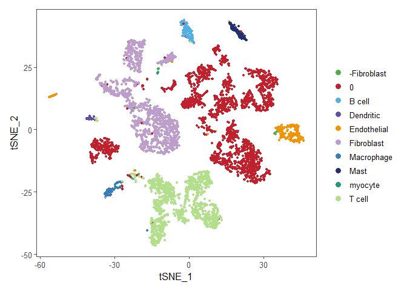

```r
library(ggplot2)
library(patchwork)
DimPlot(scRNA, reduction = 'tsne', group.by = 'non.cancer.cell.type', pt.size = 1) +
  ggthemes::theme_few() +
  scale_color_manual(values=c("#4DAF4A","#C1212D", "#54B0E4","#5E4FA2","#F29403","#BC9DCC","#377EB8",'#222F75',
                              '#1B9E77','#B2DF8A','#E3BE00'))
```

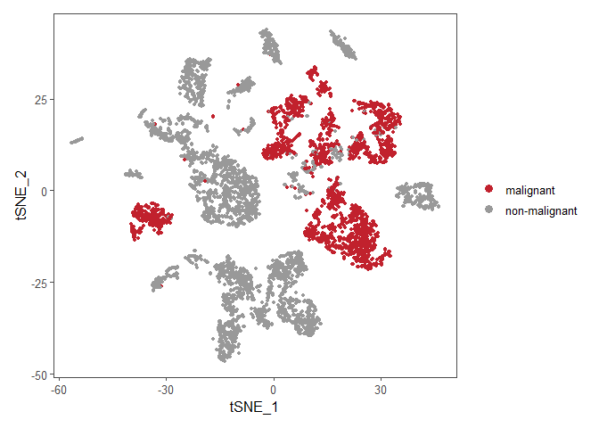

```r
DimPlot(scRNA, reduction = 'tsne', group.by = 'malignancy.annotation', pt.size = 1) +
  ggthemes::theme_few() +
  scale_color_manual(values=c('malignant'='#C1212D', 'non-malignant'='gray60'))
```

#### Malignancy annotation by SCANER

```r
library(SCANER)
set.seed(12345)
GRCh37.chrpq = SCANER::CpRMAP_GRCh37  ## or SCANER::CpRMAP_GRCh38
scaner = identificationTumorCellsX(seurat_obj=scRNA, cluster.tag='RNA_snn_res.0.4', chrpq=GRCh37.chrpq, GE.frac=0.05, smooth.ceiling=1,
                                   windows=100, cluster.NUM=30, putativeT.frac=0.5, putativeT.cor=0.5, inferCNVBy='putativeTumor2', verbose=T)
```

```
## [LOG PARAMETERS] ==================================================
## [PARAM SMOOTH CEILING]: 1
## [PARAM WINDOWS]: 100
## [PARAM FRACTION OF EXPRESSED GENES CUTOFF]: 0.05
## [PARAM PUTATIVE TUMOR CORRELATION CUTOFF]: 0.5
## [PARAM PUTATIVE TUMOR FRACTION CUTOFF]: 0.5
## [PARAM CELL NUMBER OF CLUSTER CUTOFF]: 30
## [LOG STATISTICS] ==================================================
## [STAT NUMBER OF GENES AND CELLS]: 21519 5902
## [STAT CLUSTERS]: 0 1 10 11 12 13 14 15 16 17 18 19 2 3 4 5 6 7 8 9
## [STAT NUMBER OF CELLS PER CLUSTER]: 731 657 231 218 177 162 143 122 121 117 59 46 652 538 480 368 319 263 251 247
## [STAT FRACTION OF EXPRESSED GENES PER CLUSTER]: 0.2337338 0.2290881 0.4360123 0.2934837 0.3378824 0.2868621 0.201265 0.2388572 0.2289366 0.2664587 0.2673933 0.2988203 0.4426743 0.2213591 0.421917 0.2908576 0.3801833 0.4148365 0.2636208 0.3822794
## [STAT MAD OF CN PER CLUSTER]: 0.03743405 0.03421489 0.06360567 0.04264244 0.05718296 0.0419222 0.03610115 0.03631428 0.0391379 0.04051995 0.0382711 0.04404276 0.07484382 0.0333895 0.05343609 0.04223776 0.05664282 0.073091 0.04124643 0.06131515
## [STAT TUMOR CLUSTER MASK]: 0 0 1 0 0 0 0 0 0 0 0 0 1 0 1 0 1 1 0 1
## [STAT TUMOR CLUSTER SEED FRAC]: 0.03419973 0.00913242 0.8528139 0.1697248 0.519774 0.1851852 0.01398601 0.01639344 0.07438017 0.1025641 0.03389831 0.2826087 0.9432515 0.001858736 0.79375 0.1875 0.6739812 0.8441065 0.09561753 0.7327935
## [STAT TUMOR CLUSTER SEED]: 10 12 2 4 6 7 9
## [STAT TUMOR PURITY (putativeTumor/putativeTumor2)]: 0.403592 0.3713995
```

Then we present the results of malignancy annotation by SCANER

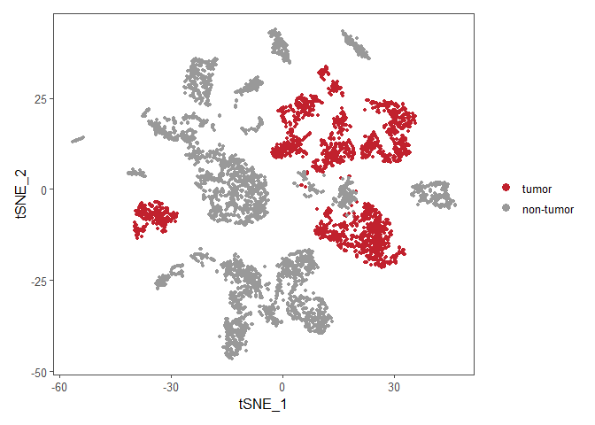

```r
scRNA@meta.data = cbind(scRNA@meta.data, scaner$information)
DimPlot(scRNA, reduction = 'tsne', group.by = 'putativeTumor2', pt.size = 1) +
  ggthemes::theme_few() +
  scale_color_manual(values=c('tumor'='#C1212D', 'non-tumor'='gray60'))
```

Plot CNV

```r
CNVPlot(scaner.rs = scaner, putativeTumor=2, genomeSizeFile='hg19', seed = 12345, outPDF='./scanerCNV.pdf')
```